# White Wine Quality Exploration

Student: George J. J. Wu

Date: February 27, 2018

```r
# Load libraries
library(ggplot2)
library(dplyr)
library(gridExtra)
library(corrplot)
library(GGally)
```

```r
# Load data
wq <- read.csv(file="wineQualityWhites.csv")
```

The current analysis examines a dataset containing physicochemical properties and quality ratings for 4,898 white wines.

# Univariate Plots Section

```r
# Dimension of dataset
dim(wq)
```

```
## [1] 4898   13
```

```r
# Structure of dataset
str(wq)
```

```
## 'data.frame':    4898 obs. of  13 variables:
##  $ X                   : int  1 2 3 4 5 6 7 8 9 10 ...
##  $ fixed.acidity       : num  7 6.3 8.1 7.2 7.2 8.1 6.2 7 6.3 8.1 ...
##  $ volatile.acidity    : num  0.27 0.3 0.28 0.23 0.23 0.28 0.32 0.27 0.3 0.22 ...
##  $ citric.acid         : num  0.36 0.34 0.4 0.32 0.32 0.4 0.16 0.36 0.34 0.43 ...
##  $ residual.sugar      : num  20.7 1.6 6.9 8.5 8.5 6.9 7 20.7 1.6 1.5 ...
##  $ chlorides           : num  0.045 0.049 0.05 0.058 0.058 0.05 0.045 0.045 0.049 0.044 ...
##  $ free.sulfur.dioxide : num  45 14 30 47 47 30 30 45 14 28 ...
##  $ total.sulfur.dioxide: num  170 132 97 186 186 97 136 170 132 129 ...
##  $ density             : num  1.001 0.994 0.995 0.996 0.996 ...
##  $ pH                  : num  3 3.3 3.26 3.19 3.19 3.26 3.18 3 3.3 3.22 ...
##  $ sulphates           : num  0.45 0.49 0.44 0.4 0.4 0.44 0.47 0.45 0.49 0.45 ...
##  $ alcohol             : num  8.8 9.5 10.1 9.9 9.9 10.1 9.6 8.8 9.5 11 ...
##  $ quality             : int  6 6 6 6 6 6 6 6 6 6 ...
```

```r
# Check for missing values
table(is.na(wq))
```

```
##
## FALSE
## 63674
```

The current dataset contains 13 variables and 4,898 observations. There are no missing values in the dataset. There are 11 variables associated with the physicochemical attributes of white wine, and 1 output variable associated with the quality ratings of white wine.

### Wine Quality

Wine quality is rated on a 0 to 10 scale, with 0 being the lowest quality and 10 being the highest quality.

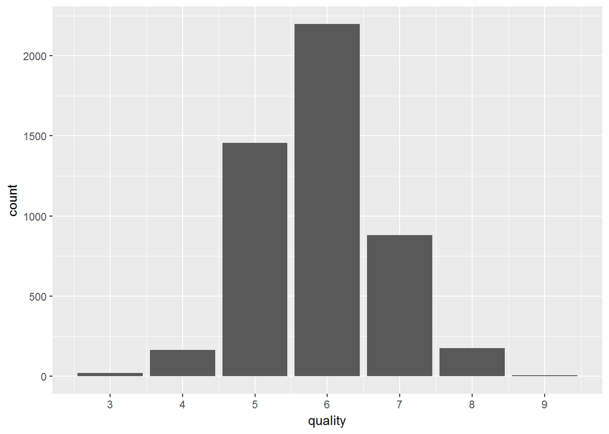

```r
# visualize wine quality
ggplot(aes(x = quality), data = wq) +
  geom_histogram(stat="count") +
  scale_x_continuous(breaks = seq(3, 9 ,1))
```

```r
# numeric examination of wine quality distribution
table(wq$quality)
```

```
##
##    3    4    5    6    7    8    9
##   20  163 1457 2198  880  175    5
```

```r
# descriptive stats of wine quality distribution
summary(wq$quality)
```

```
##    Min. 1st Qu.  Median    Mean 3rd Qu.    Max.
##   3.000   5.000   6.000   5.878   6.000   9.000
```

Most white wines in the dataset are given a quality rating of 6, with 3 being the lowest quality rating given, and 9 being the highest quality rating given. To facilitate further comparisons, the current analysis considers wines with a quality rating of 5 or lower as low quality, wines with a quality rating of 6 as medium quality, and wines with a quality rating of 7 or higher as high quality.

```r
# create new variable quality groups
# 3 to 5 low quality, 6 medium quality, 7 to 9 high quality
wq$quality.groups <- cut(wq$quality, breaks = c(0, 5, 6, 9),
                         labels = c("low", "medium", "high"))
```

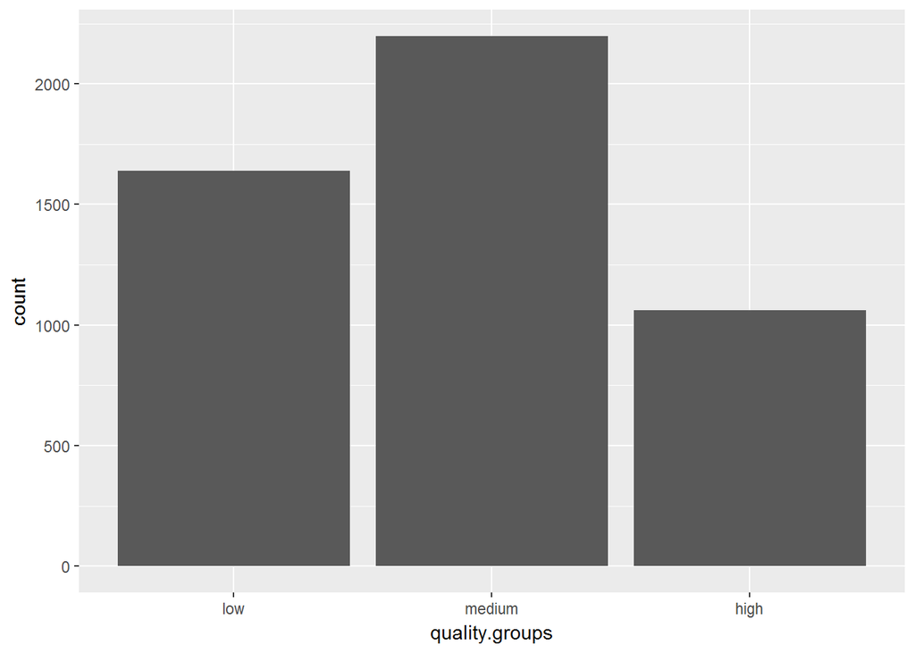

```r
# visualize wine quality groups
ggplot(aes(x = quality.groups), data = subset(wq, !is.na(quality.groups))) +
  geom_histogram(stat = "count")
```

```r
# descriptive stats of wine quality groups
summary(wq$quality.groups)
```

```
##    low medium   high
##   1640   2198   1060
```

Converting wine quality to a categorical variable has yielded three sizable wine quality groups, each with at least 1,000 observations.

### Physicochemical Attributes

To ease comparisons, the current analysis categorizes the 11 physicochemical attributes of white wines into the following groups:

- Acid-related attributes: fixed acidity, volatile acidity, citric acidity, pH
- Sugar and salt attributes: residual sugar, chlorides
- Sulfur-related attributes: free sulfur dioxide, total sulfur dioxide, sulphates
- Other attributes: density, alcohol

#### Acid-related Attributes

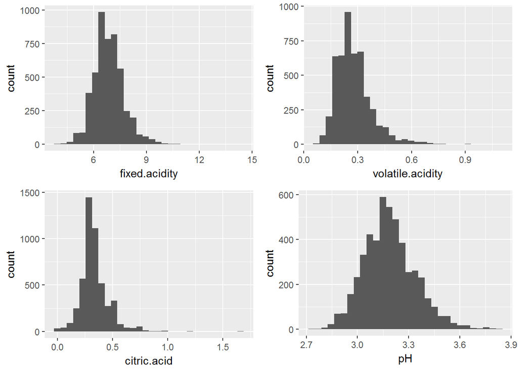

```r
# visualize acid-related attributes
u1 <- ggplot(aes(x = fixed.acidity), data = wq) +
  geom_histogram()

u2 <- ggplot(aes(x = volatile.acidity), data = wq) +
  geom_histogram()

u3 <- ggplot(aes(x = citric.acid), data = wq) +
  geom_histogram()

u4 <- ggplot(aes(x = pH), data = wq) +
  geom_histogram()

grid.arrange(u1, u2, u3, u4)
```

```r
# descriptive stats for acid-related attributes
summary(wq[ , c("fixed.acidity", "volatile.acidity",
                "citric.acid", "pH")])
```

```
##  fixed.acidity    volatile.acidity  citric.acid           pH
##  Min.   : 3.800   Min.   :0.0800   Min.   :0.0000   Min.   :2.720
##  1st Qu.: 6.300   1st Qu.:0.2100   1st Qu.:0.2700   1st Qu.:3.090
##  Median : 6.800   Median :0.2600   Median :0.3200   Median :3.180
##  Mean   : 6.855   Mean   :0.2782   Mean   :0.3342   Mean   :3.188
##  3rd Qu.: 7.300   3rd Qu.:0.3200   3rd Qu.:0.3900   3rd Qu.:3.280
##  Max.   :14.200   Max.   :1.1000   Max.   :1.6600   Max.   :3.820
```

Both visual and numeric examinations of acid-related attributes suggest that white wines are acidic in nature. Note that high levels of volatile acidity can lead to an unpleasant taste of wine. Most wines in the dataset are measured 6.3 to 7.3 (g/dm^3) in fixed acidity, 0.21 to 0.32 (g/dm^3) in volatile acidity, 0.27 to 0.39 (g/dm^3) in citric acid quantity, and 3.09 to 3.28 in terms of pH value. There seem to be outliers on both ends of the fixed acidity variable, on the high end of the volatile acidity variable, as well as on the high end of the citric acid variable.

### Sugar and Salt Attributes

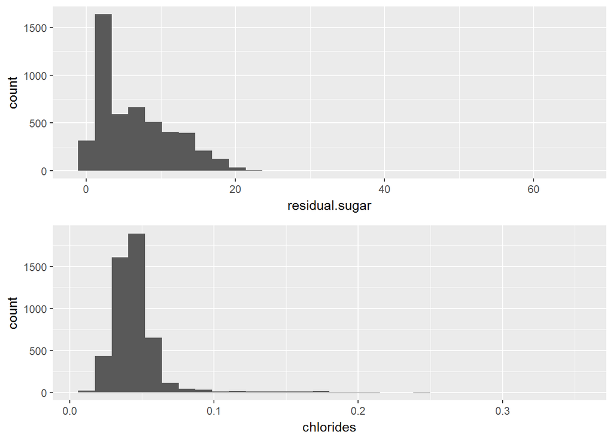

```r
# visualize sugar and chlorides
u4 <- ggplot(aes(x = residual.sugar), data = wq) +
  geom_histogram()

u5 <- ggplot(aes(x = chlorides), data = wq) +
  geom_histogram()

grid.arrange(u4, u5)
```

```r
# numeric examinations of sugar and chlorides
summary(wq[ , c("residual.sugar", "chlorides")])
```

```
##  residual.sugar     chlorides
##  Min.   : 0.600   Min.   :0.00900
##  1st Qu.: 1.700   1st Qu.:0.03600
##  Median : 5.200   Median :0.04300
##  Mean   : 6.391   Mean   :0.04577
##  3rd Qu.: 9.900   3rd Qu.:0.05000
##  Max.   :65.800   Max.   :0.34600
```

White wines seem to contain a small amount of residual sugar and chlorides in general. Most wines in the dataset are measured 1.7 to 9.9 (g/dm^3) in residual sugar quantity, and 0.036 to 0.05 (g/dm^3) in chlorides quantity. The distribution of both variables are somewhat right-skewed, and there seem to be outliers on the high end of both variables.

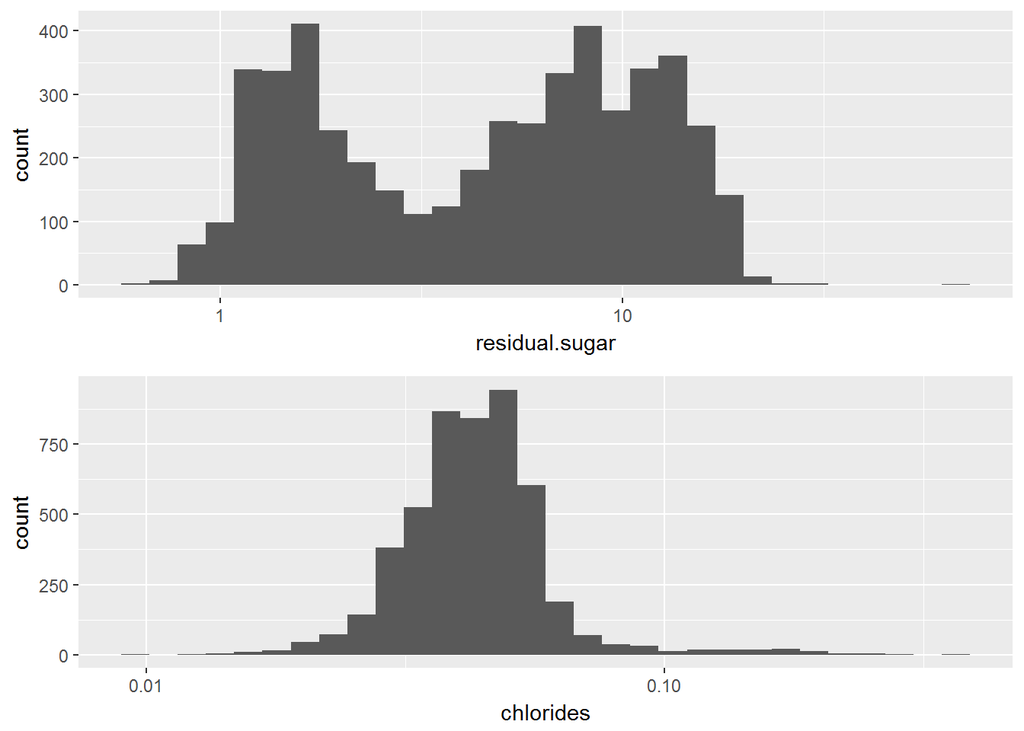

```r
# log-transform sugar and chlorides, and visualize
u42 <- ggplot(aes(x = residual.sugar), data = wq) +
  geom_histogram() +
  scale_x_log10()

u52 <- ggplot(aes(x = chlorides), data = wq) +
  geom_histogram() +
  scale_x_log10()

grid.arrange(u42, u52)
```

Performing log transformations to both variables reveal a somewhat bimodal distribution for residual sugar, and an approximately normal distribution for chlorides.

### Sulfur-related Attributes

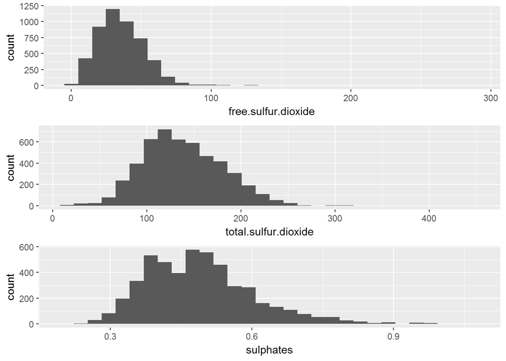

```r
# visualize sulfur-related attributes
u6 <- ggplot(aes(x = free.sulfur.dioxide), data = wq) +
  geom_histogram()

u7 <- ggplot(aes(x = total.sulfur.dioxide), data = wq) +
  geom_histogram()

u8 <- ggplot(aes(x = sulphates), data = wq) +
  geom_histogram()

grid.arrange(u6, u7, u8)
```

```r
# numeric examination of sulfur-related attributes
summary(wq[ , c("free.sulfur.dioxide", "total.sulfur.dioxide",
                "sulphates")])
```

```
##  free.sulfur.dioxide total.sulfur.dioxide   sulphates
##  Min.   :  2.00      Min.   :  9.0        Min.   :0.2200
##  1st Qu.: 23.00      1st Qu.:108.0        1st Qu.:0.4100
##  Median : 34.00      Median :134.0        Median :0.4700
##  Mean   : 35.31      Mean   :138.4        Mean   :0.4898
##  3rd Qu.: 46.00      3rd Qu.:167.0        3rd Qu.:0.5500
##  Max.   :289.00      Max.   :440.0        Max.   :1.0800
```

Sulfur dioxide prevents microbial growth and slows oxidation of wine, but high concentration of sulfur dioxide can impact taste of wine. Most white wines in the dataset contain 23 to 46 (mg/dm^3) of free form sulfur dioxide, 108 to 167 (mg/dm^3) of sulfur dioxide in total (free form and bound form), as well as 0.41 to 0.55 (g/dm^3) of sulphates. There seem to be outliers on both ends of all three variables. Note that free form sulfur dioxide and total sulfur dioxide are both measured in milligram per decimeter cubed (mg/dm^3).

### Other Attributes

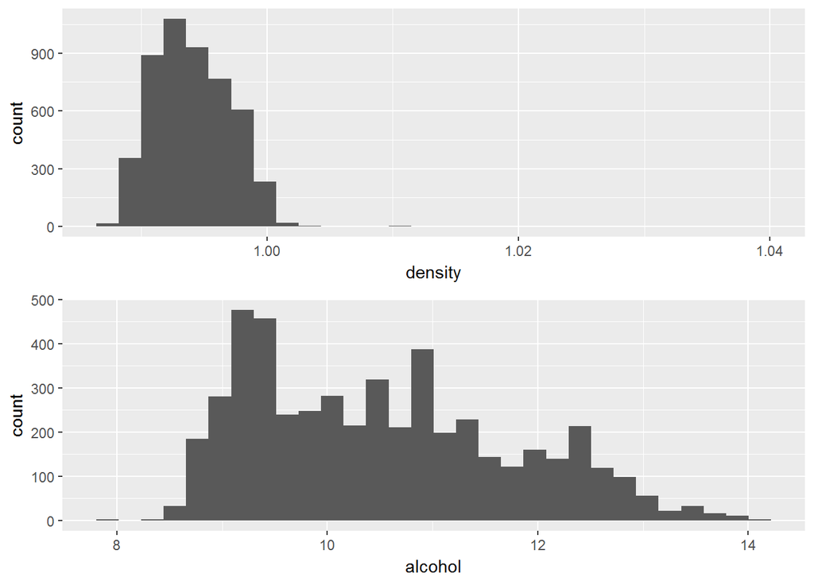

```r
# visualize density and alcohol
u9 <- ggplot(aes(x = density), data = wq) +
  geom_histogram()

u10 <- ggplot(aes(x = alcohol), data = wq) +
  geom_histogram()

grid.arrange(u9, u10)
```

```r
# numeric examination of density and alcohol
summary(wq[ , c("density", "alcohol")])
```

```
##     density          alcohol
##  Min.   :0.9871   Min.   : 8.00
##  1st Qu.:0.9917   1st Qu.: 9.50
##  Median :0.9937   Median :10.40
##  Mean   :0.9940   Mean   :10.51
##  3rd Qu.:0.9961   3rd Qu.:11.40
##  Max.   :1.0390   Max.   :14.20
```

The density of a white wine should be associated with its sugar content and percent alcohol. Most wines in the dataset have a density between 0.9917 to 0.9961 (g/cm^3), and alcohol content between 9.5 to 11.4 (percent by volume). The distribution of alcohol content seems to be somewhat multimodal. There seem to be outliers on the high end of the density variable.

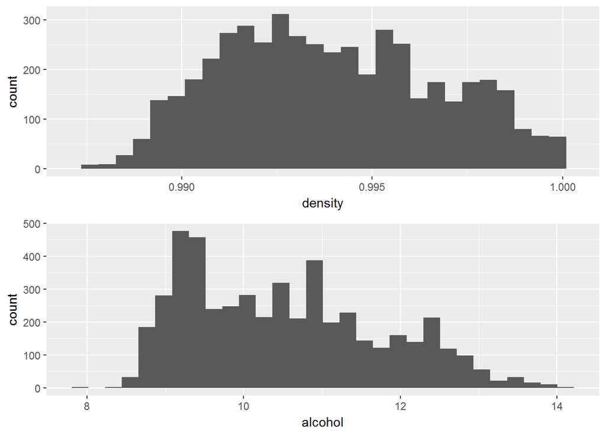

```r
# exclude top 1% quantile from density and visualize
u92 <- ggplot(aes(x = density), data = wq) +
  geom_histogram() +
  xlim(quantile(wq$density, 0), quantile(wq$density, 0.99))

u10 <- ggplot(aes(x = alcohol), data = wq) +
  geom_histogram()

grid.arrange(u92, u10)
```

Excluding the top 1% of observations in the density variable reveals a somewhat normal distribution for the remaining observations.

# Univariate Analysis

### What is the structure of your dataset?

There are 4,898 white wines in the current dataset with 12 features, as follows:

- quality rating
- fixed acidity
- volatile acidity
- citric acid
- pH
- residual sugar
- chlorides
- free sulfur dioxide
- total sulfur dioxide
- sulphates
- density
- alcohol content

### What is/are the main feature(s) of interest in your dataset?

The main feature of interest for the current analysis is wine quality rating.

### What other features in the dataset do you think will help support your investigation into your feature(s) of interest?

Wine quality rating should be theoretically associated with the following features:

- alcohol content
- volatile acidity
- total sulfur dioxide

### Did you create any new variables from existing variables in the dataset?

To facilitate comparisons, the current analysis converts wine quality into a new categorical variable named *quality groups* with only three levels: low quality (3 to 5), medium quality (6), and high quality (7 to 9).

### Of the features you investigated, were there any unusual distributions? Did you perform any operations on the data to tidy, adjust, or change the form of the data? If so, why did you do this?

The right-skewed residual sugar and chlorides variables have been log-transformed, revealing a somewhat bimodal distribution for residual sugar, and an approximately normal distribution for chlorides. The top 1% of observations for the density variable has also been excluded from visualization for formatting purposes.

# Bivariate Plots Section

### Correlation Matrix

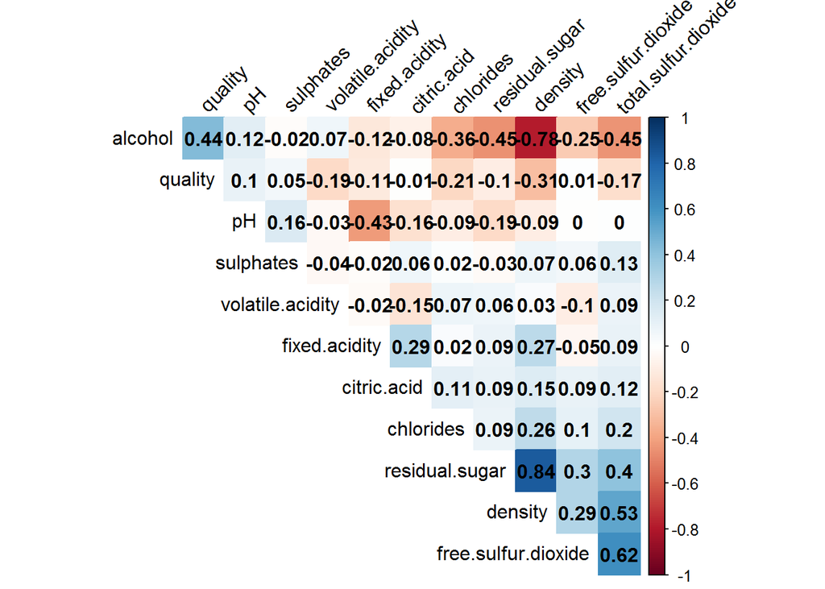

```r
# compute correlations
cm <-cor(wq[, 2:13], method = "pearson")

# map correlations to matrix
corrplot(cm, method = "color", type = "upper", order = "hclust",
         tl.col = "black", tl.srt = 45, addCoef.col = "black",
         diag = FALSE)
```

White wine quality rating is moderately correlated with alcohol content (r = .44) and density (r = -.31), and weakly correlated with chlorides (r = -.21), volatile acidity (r = -.19), and total sulfur dioxide level (r = -.17). Perhaps unsurprisingly, density is strongly correlated with residual sugar level (r = .84) and negatively correlated with alcohol content (r = -.78). Note that all outliers are included in the correlation calculations.

Let’s take a closer look at the relationship between quality and alcohol content, the relationship between quality and density, as well as the relationship between alcohol content and density.

### Quality and Alcohol

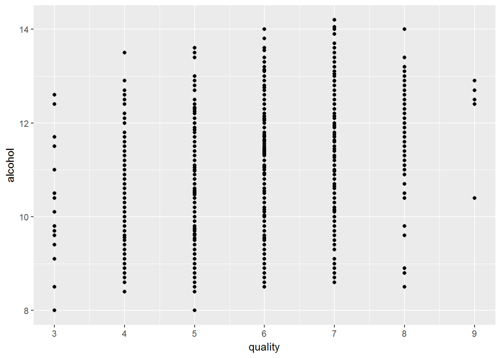

```r
# visualize quality and alcohol
ggplot(aes(x = quality, y = alcohol), data = wq) +
  geom_point() +
  scale_x_continuous(breaks = seq(3, 9 ,1))
```

All quality ratings in the dataset are integers. Thus, adding jitter, increasing transparency, and introducing a linear regression line should reduce overplotting, and help visualize the moderate relationship between wine quality and alcohol content.

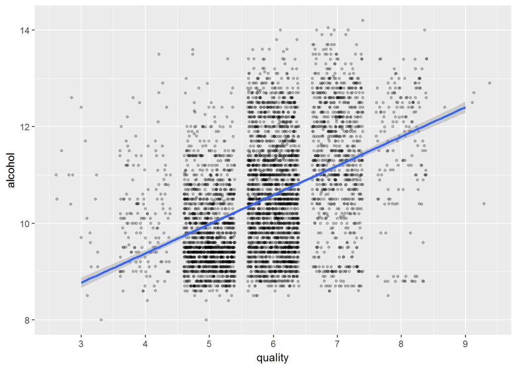

```r
# add jitter and linear regression line
ggplot(aes(x = quality, y = alcohol), data = wq) +
  geom_point(alpha = 1/4, size = 1, position = "jitter") +
  geom_smooth(method = "lm") +
  scale_x_continuous(breaks = seq(3, 9 ,1))
```

As the alcohol content of white wine increases, quality rating also tends to increase, albeit there is still a lot of noise in the above visualization. Turning to the newly created quality groups variable should produce a more abstract view of the relationship between quality and alcohol content.

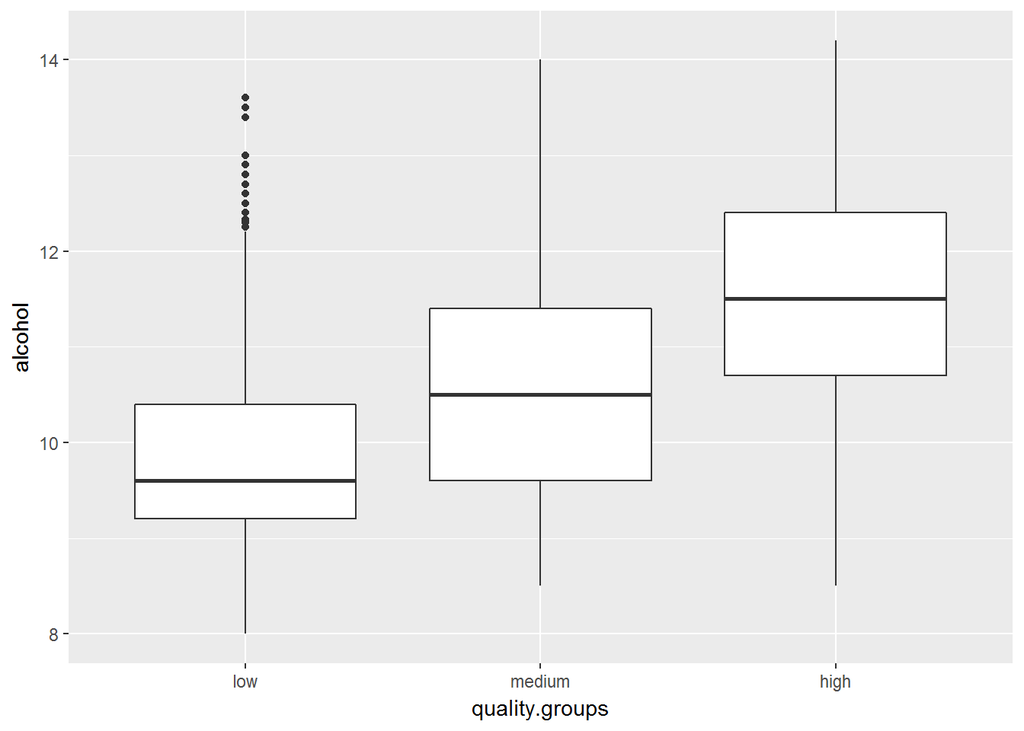

```r
# visualize quality groups and alcohol
ggplot(aes(x = quality.groups, y = alcohol), data = wq) +
  geom_boxplot()
```

```r
# numeric examination of quality groups and alcohol
by(wq$alcohol, wq$quality.groups, summary)
```

```
## wq$quality.groups: low
##    Min. 1st Qu.  Median    Mean 3rd Qu.    Max.
##    8.00    9.20    9.60    9.85   10.40   13.60
## --------------------------------------------------------
## wq$quality.groups: medium
##    Min. 1st Qu.  Median    Mean 3rd Qu.    Max.
##    8.50    9.60   10.50   10.58   11.40   14.00
## --------------------------------------------------------
## wq$quality.groups: high
##    Min. 1st Qu.  Median    Mean 3rd Qu.    Max.
##    8.50   10.70   11.50   11.42   12.40   14.20
```

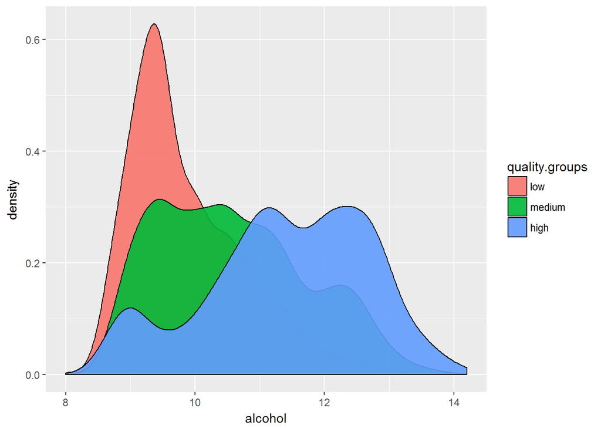

```r
# density plot for alcohol by quality group
ggplot(aes(x = alcohol, fill = quality.groups), data = wq) +
  geom_density(alpha = 0.9)
```

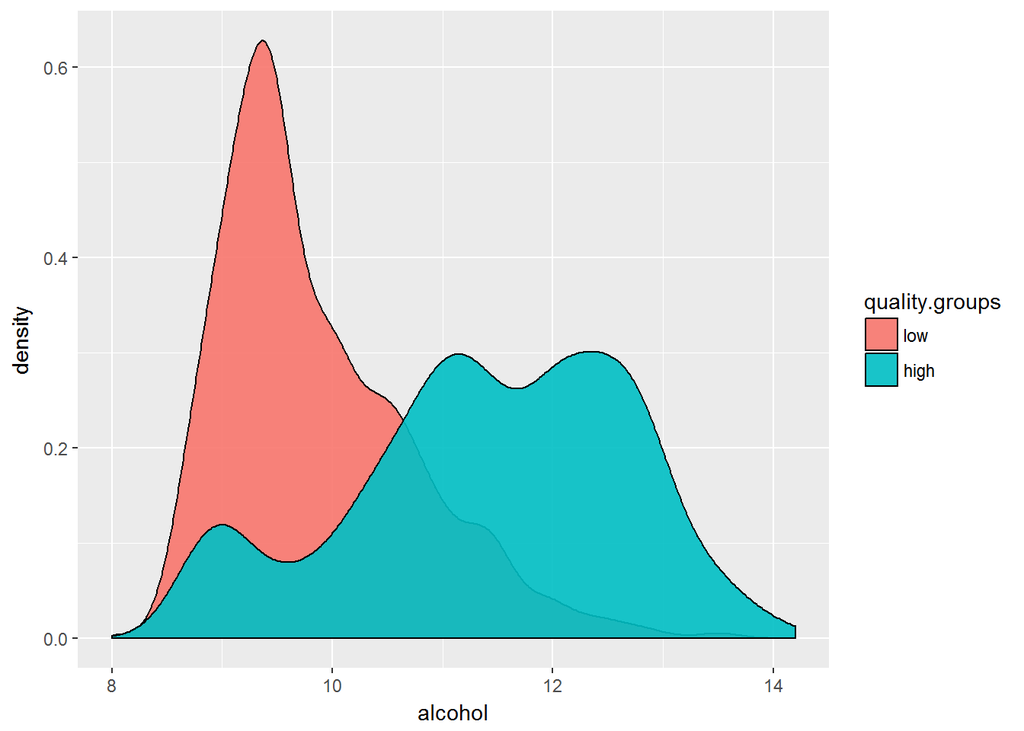

```r
# exclude medium quality group
wq.hl <- wq[wq$quality.groups != "medium", ]

# density plot for alcohol by high and low quality groups
ggplot(aes(x = alcohol, fill = quality.groups), data = wq.hl) +
  geom_density(alpha = 0.9)
```

### Quality and Density

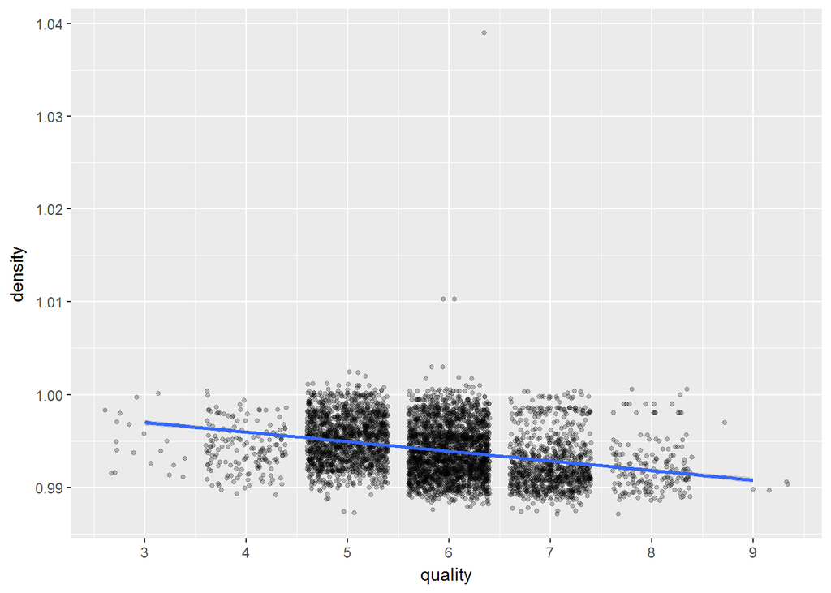

```r
# visualize quality and density
ggplot(aes(x = quality, y = density), data = wq) +
  geom_point(alpha = 1/4, size = 1, position = "jitter") +
  geom_smooth(method = "lm") +
  scale_x_continuous(breaks = seq(3, 9 ,1))
```

Omitting the top 1% of observations from density to get a better view of the relationship between quality rating and density.

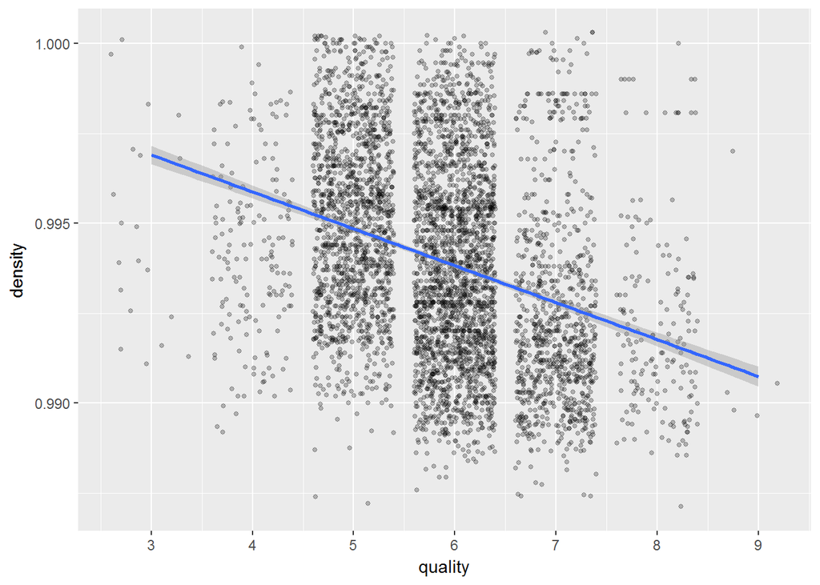

```r
# add jitter and linear regression line
# exclude top 1% of data from density
ggplot(aes(x = quality, y = density), data = wq) +
  geom_point(alpha = 1/4, size = 1, position = "jitter") +
  geom_smooth(method = "lm") +
  ylim(quantile(wq$density, 0), quantile(wq$density, 0.99)) +
  scale_x_continuous(breaks = seq(3, 9 ,1))
```

Note that jitter, transparency, and a linear regression line has been added to the above visualization, which suggests an inverse relationship between density and quality rating. As the density of white wine decreases, quality rating tends to increase. Turning to the quality groups variable once again to get a more abstract view of the relationship between quality and density.

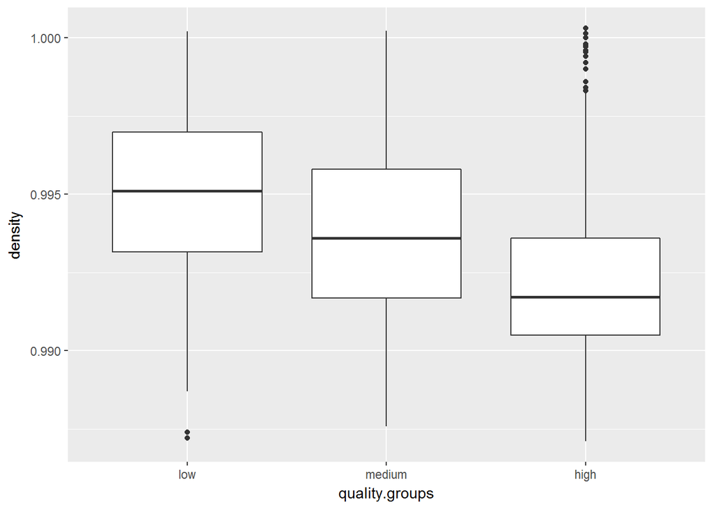

```r
# visualize density and quality groups
ggplot(aes(x = quality.groups, y = density),
       data = subset(wq, !is.na(quality.groups))) +
  geom_boxplot() +
  ylim(quantile(wq$density, 0), quantile(wq$density, 0.99))
```

```r
# numeric examination of density and quality groups
by(wq$density, wq$quality.groups, summary)
```

```
## wq$quality.groups: low
##    Min. 1st Qu.  Median    Mean 3rd Qu.    Max.
##  0.9872  0.9932  0.9951  0.9952  0.9971  1.0024
## --------------------------------------------------------
## wq$quality.groups: medium
##    Min. 1st Qu.  Median    Mean 3rd Qu.    Max.
##  0.9876  0.9917  0.9937  0.9940  0.9959  1.0390
## --------------------------------------------------------
## wq$quality.groups: high
##    Min. 1st Qu.  Median    Mean 3rd Qu.    Max.
##  0.9871  0.9905  0.9917  0.9924  0.9936  1.0006
```

Note that the top 1% of observations from density has been omitted from the visualization. The low quality group produced a median density of 0.9951 (g/cm^3), the medium quality group produced a median density of 0.9937 (g/cm^3), whereas the high quality group produced a median density of 0.9917 (g/cm^3). In spite of outliers in all three quality groups, the general pattern seems to be that density decreases as quality rating increases. This pattern should be also observed in a density plot, as follows:

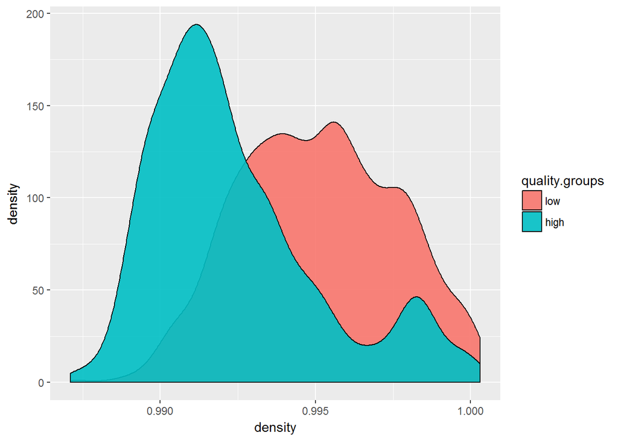

```r
# density plot of density by quality groups
ggplot(aes(x = density, fill = quality.groups),
       data = subset(wq.hl, !is.na(quality.groups))) +
  geom_density(alpha = 0.9) +
  xlim(quantile(wq$density, 0), quantile(wq$density, 0.99))
```

Note that the medium quality group has been omitted from the density plot to simplify comparisons, and that the y-axis refers to the density scale, and not the density attribute of white wine. The top 1% of observations from the density attribute has been omitted from this plot. The distribution of wine density is rather different between the low and high quality groups, with the low quality group peaks at around 0.995 (g/cm^3), and the high quality group peaks at around 0.992 (g/cm^3). High quality white wines seem to have, on average, lower density than their low quality counterparts.

### Density and Alcohol

Given the moderate relationship between quality and alcohol content, as well as the inverse relationship between quality and density, the current analysis expects alcohol and density to be also inversely related.

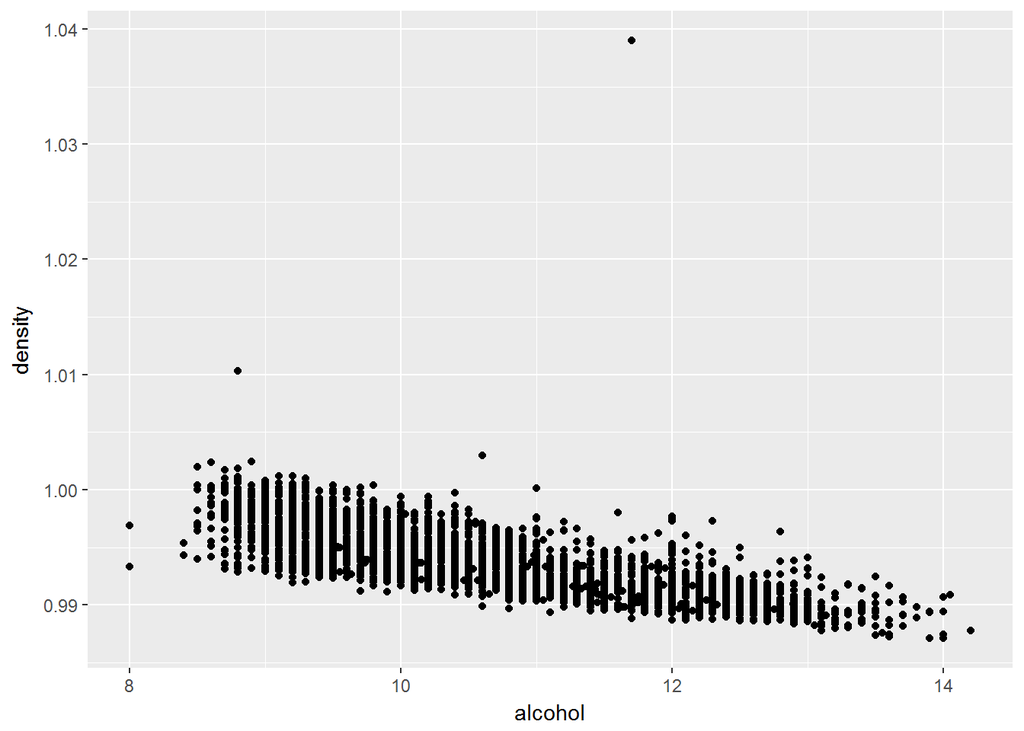

```r
# visualize alcohol and density
ggplot(aes(x = alcohol, y = density), data = wq) +
  geom_point()
```

Omitting the top 1% of observations from density to get a better view of the relationship between alcohol content and density.

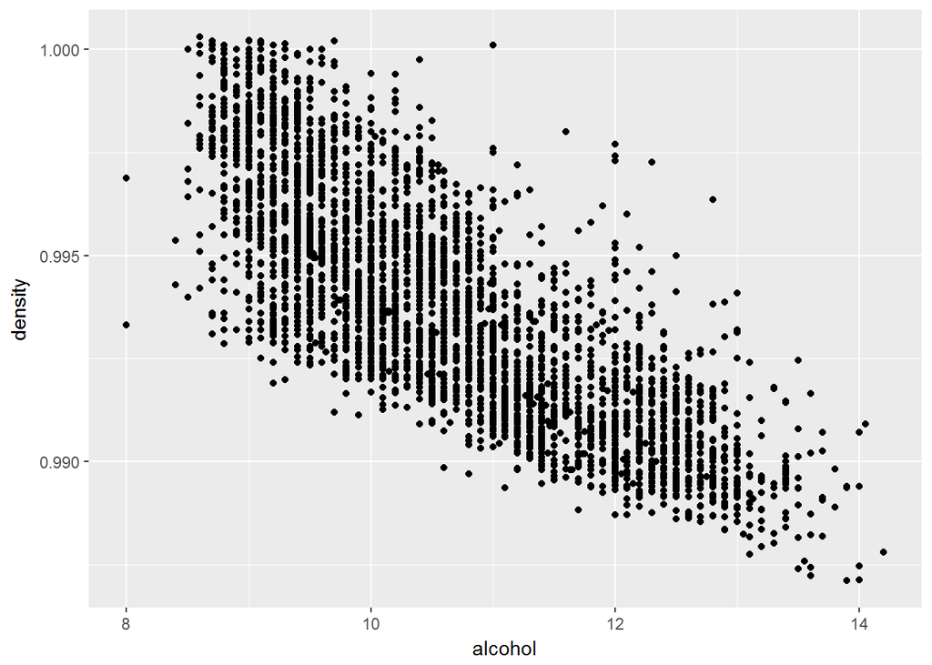

```r
# exclude top 1% of data from density
ggplot(aes(x = alcohol, y = density), data = wq) +
  geom_point() +
  ylim(quantile(wq$density, 0), quantile(wq$density, 0.99))
```

Increasing transparency and fitting a linear regression smoother to reduce overplotting.

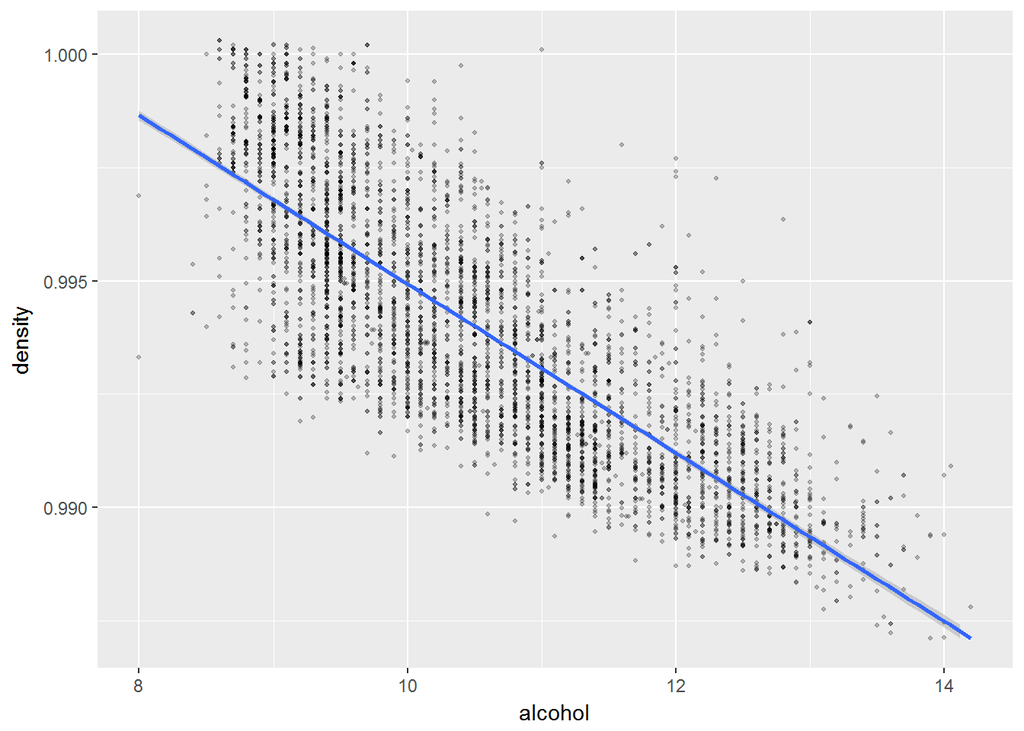

```r
# add transparency and linear regression line
ggplot(aes(x = alcohol, y = density), data = wq) +
  geom_point(alpha = 1/4, size = 3/4) +
  ylim(quantile(wq$density, 0), quantile(wq$density, 0.99)) +
  geom_smooth(method = "lm")
```

Consistent with expectations, as alcohol content increases, wine density tends to decrease.

# Bivariate Analysis

### Talk about some of the relationships you observed in this part of the investigation. How did the feature(s) of interest vary with other features in the dataset?

The main feature of interest for the current report is quality rating. Bivariate analysis suggests that quality rating is moderately associated with alcohol content, and inversely associated with wine density. As wine quality rating increases, alcohol content also tends to increase, and wine density tends to decrease. Wine quality rating is also weakly and inversely associated with the levels of chlorides, volatile acidity, and total sulfur dioxide.

### Did you observe any interesting relationships between the other features (not the main feature(s) of interest)?

Consistent with intuitions, wine density is strongly associated with the amount of residual sugar in wine, but is inversely associated with the amount of alcohol content.

### What was the strongest relationship you found?

The strongest relationship found in the current dataset is the relationship between wine density and residual sugar (r = .84).

# Multivariate Plots Section

### Density and Alcohol by Wine Quality

Let’s examine the relationship between density and alcohol content across the three wine quality groups.

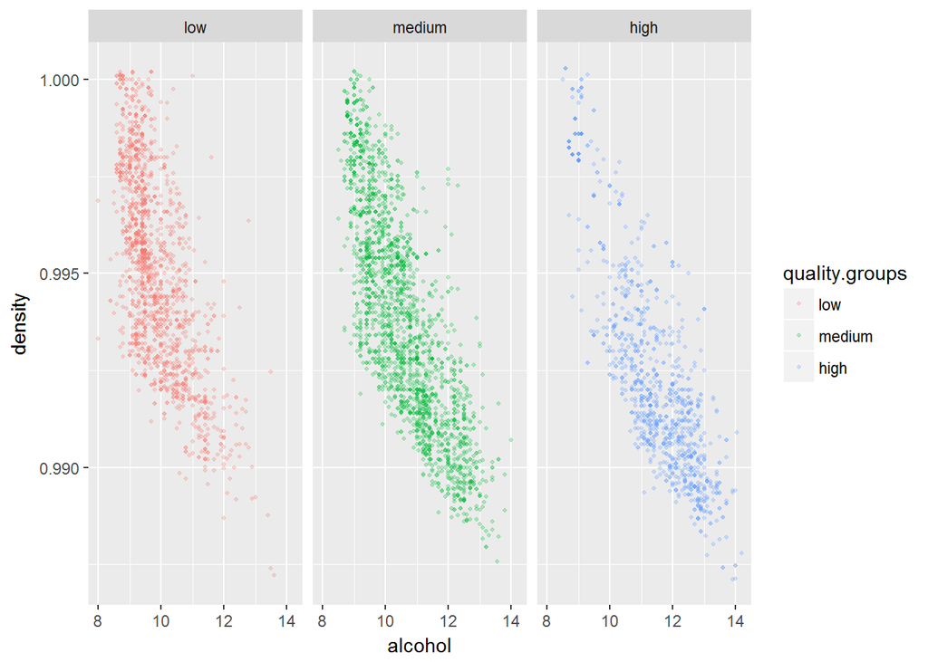

```r
# visualize alcohol and density by quality groups
ggplot(aes(x = alcohol, y = density, color = quality.groups),
       data = wq) +
  geom_point(alpha = 1/4, size = 3/4) +
  ylim(quantile(wq$density, 0), quantile(wq$density, 0.99)) +
  facet_wrap(~quality.groups)
```

Consistent with the styling choices made in the bivariate analysis, the top 1% of the observations from density has been excluded from the visualization, and transparency has been added to reduce overplotting. The resulting plot indicates that the inverse relationship between density and alcohol largely persists across the three quality groups. Nonetheless, there seem to be some differences between the low quality group and the high quality group in terms of how the observations are distributed. Let’s take a closer look at these differences by omitting the medium quality group for the time being.

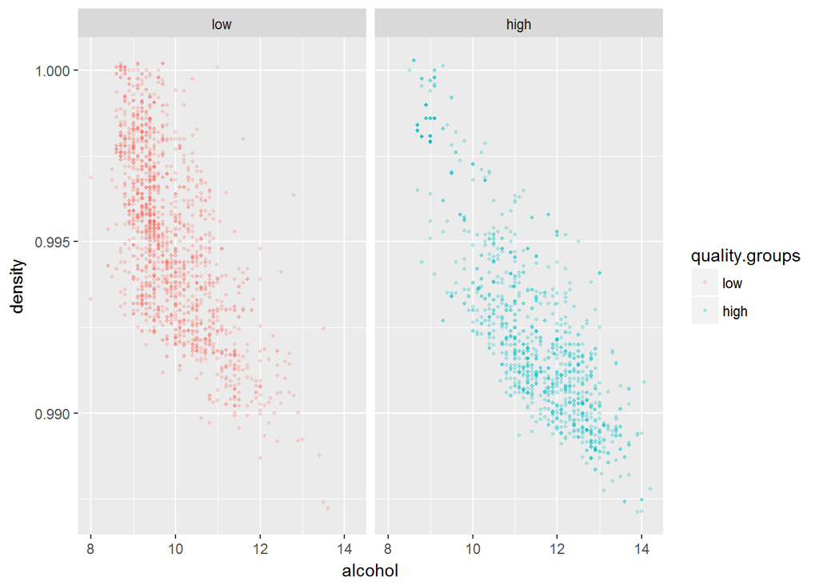

```r
# exclude medium quality group
ggplot(aes(x = alcohol, y = density, color = quality.groups),
       data = wq.hl) +
  geom_point(alpha = 1/4, size = 3/4) +
  ylim(quantile(wq$density, 0), quantile(wq$density, 0.99)) +
  facet_wrap(~quality.groups)
```

Overlaying plots from the two quality groups on top of each other should further facilitate comparisons.

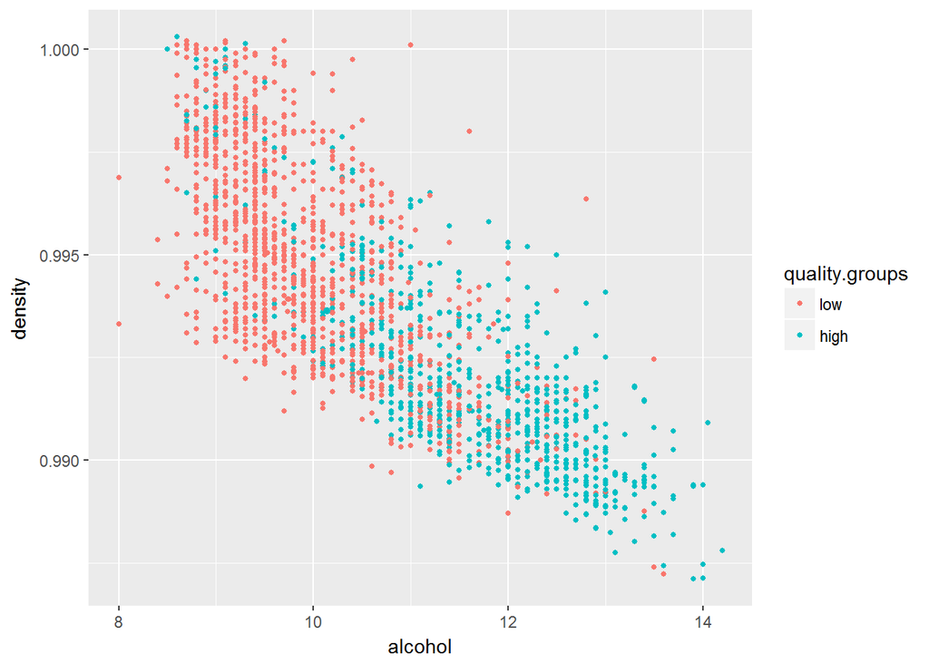

```r
# overlay two plots
ggplot(aes(x = alcohol, y = density, color = quality.groups),
       data = wq.hl) +
  geom_point(alpha = 1, size = 1) +
  ylim(quantile(wq$density, 0), quantile(wq$density, 0.99))
```

The above plot suggests that high quality white wines tend to have high levels of alcohol content and low levels of density, whereas low quality white wines tend to have low levels of alcohol content and high levels of density.

### Attributes of High Quality White Wines

To save work, let’s identify the key characteristics of high quality white wines by plotting a number of attributes on a scatterplot matrix. Alcohol content, density, chlorides (log transformed), volatile acidity level, and total sulfur dioxide level will be included in the matrix based on their correlations to wine quality rating.

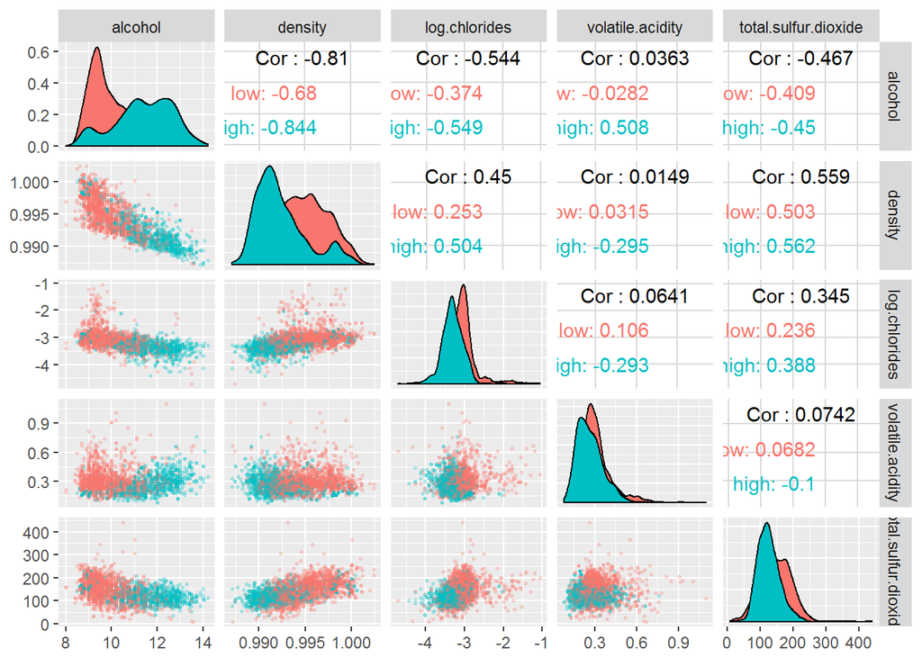

```r
# log transform chloride
wq.hl$log.chlorides <- log(wq.hl$chlorides)

# generate scatterplot matrix
# add transparency
ggpairs(wq.hl,
        mapping = aes(color = quality.groups),
        columns = c("alcohol", "density", "log.chlorides",
                    "volatile.acidity", "total.sulfur.dioxide"),
        lower = list(continuous = wrap("points",
                                       alpha = 1/4, size = 0.5)))
```

Note that medium quality group is omitted from the visualization to simplify comparisons, and transparency is added to each scatterplot to reduce overplotting. When compared to low quality white wines, high quality white wines seem to be have the following characteristics:

- relatively high level of alcohol content
- relatively low level of density
- low level of chlorides
- low level of volatile acidity
- low level of total sulfur dioxide

Furthermore, there are some interesting interactions among variables as suggested by the partial correlations in the upper half of the matrix. Specifically, there is a somewhat strong relationship between alcohol content and volatile acidity for high quality white wines, but not for their low quality counterparts. Similarly, there is an inverse relationship between density and volatile acidity for high quality white wines, but this pattern is not observed for low quality white wines. Note that these correlations are calculated without the observations from the medium quality groups.

# Multivariate Analysis

### Talk about some of the relationships you observed in this part of the investigation. Were there features that strengthened each other in terms of looking at your feature(s) of interest?

The inverse relationship between alcohol content and density persists across low, medium, and high quality groups. However, there are some differences between the low quality group and the high quality group in terms of how the observations are distributed. Specifically, low quality white wines typically have lower levels of alcohol content and higher levels of density, whereas high quality white wines typically have higher levels of alcohol content and lower levels of density.

### Were there any interesting or surprising interactions between features?

There are some interesting interactions among wine attributes. Specifically, there seems to be a moderate relationship between alcohol content and volatile acidity for high quality white wines, but not for low quality white wines. Similarly, there seems to be a weak and inverse relationship between density and volatile acidity for high quality white wines, but not for their low quality counterparts.

# Final Plots and Summary

### Plot One

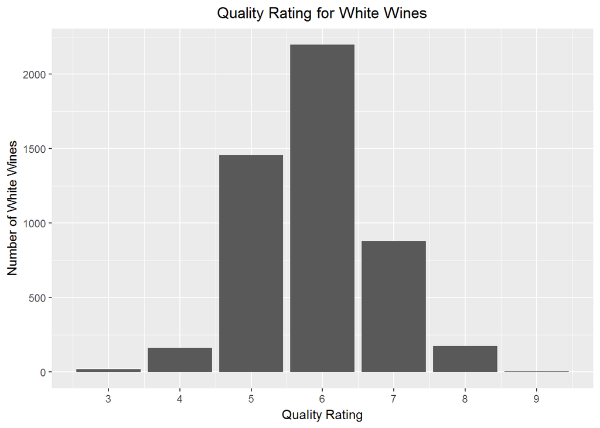

```r
ggplot(aes(x = quality), data = wq) +
  geom_histogram(stat="count") +
  scale_x_continuous(breaks = seq(3, 9 ,1)) +
  ylab("Number of White Wines") +
  xlab("Quality Rating") +
  ggtitle("Quality Rating for White Wines") +
  theme(plot.title = element_text(hjust = 0.5))
```

### Plot Two

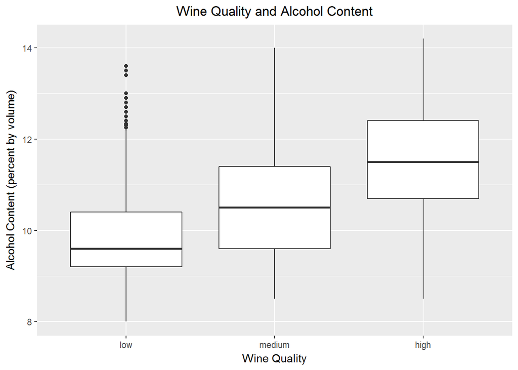

```r
ggplot(aes(x = quality.groups, y = alcohol), data = wq) +
  geom_boxplot() +
  ylab("Alcohol Content (percent by volume)") +
  xlab("Wine Quality") +
  ggtitle("Wine Quality and Alcohol Content") +
  theme(plot.title = element_text(hjust = 0.5))
```

### Plot Three

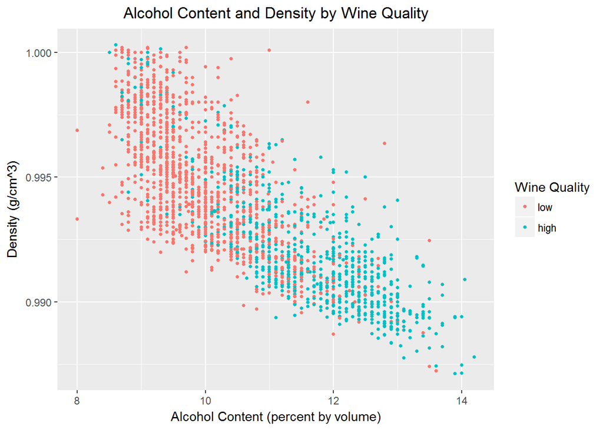

```r
ggplot(aes(x = alcohol, y = density, color = quality.groups),
       data = wq.hl) +
  geom_point(alpha = 1, size = 1) +
  ylim(quantile(wq$density, 0), quantile(wq$density, 0.99)) +
  xlab("Alcohol Content (percent by volume)") +
  ylab("Density (g/cm^3)") +
  ggtitle("Alcohol Content and Density by Wine Quality") +
  labs(color = "Wine Quality") +
  theme(plot.title = element_text(hjust = 0.5))
```

### Description Three

There is an inverse relationship between alcohol content and density across both low wine quality (3 to 5 rating) and high wine quality (7 to 9 rating) groups. Nonetheless, there are some differences between the two quality groups in terms of how the observations are distributed. Specifically, low quality white wines seem to have low levels of alcohol content and high levels of density, whereas high quality white wines seem to have high levels of alcohol content and low levels of density. Note that the top 1% of the observations from density has been excluded from the visualization.

# Reflection

The current analysis aims to identify key physicochemical attributes that are associated with the quality rating of white wines. Toward this goal, the current analysis examined the distribution of each of the variables in the dataset, as well as the relationships and interactions among these variables. Both visual and numeric examinations suggest that high quality white wines, when compared to their low quality counterparts, seem to be have the following characteristics:

- Relatively high level of alcohol content
- Relatively low level of density
- Low level of chlorides
- Low level of volatile acidity
- Low level of total sulfur dioxide

The current investigation nonetheless encountered a number of issues over the course of data exploration, specifically:

- The current investigation initially struggled to conceptualize and visualize wine quality rating as a continuous variable, because all quality ratings in the dataset are integers. This issue is eventually encountered by adding jitter to visualizations, and by creating a new categorical variable named wine quality groups to simplify comparisons.
- Many variables in the dataset contain extreme outliers. These outliers can skew variable distributions, and often made univariate visualization challenging. The current analysis decided that many of the outliers in the dataset are actually meaningful, and chose not to exclude outliers from numeric computations. Only some extreme values were excluded from visualizations for styling purposes.

Follow-up analysis can benefit by building a linear model to predict white wine quality rating by using various physicochemical attributes as input.